# BVAR

Pedro Valls

2022-11-16

## Clear workspace

```r
rm(list = ls())
```

## Change working drectory

```r
setwd("C:/Users/Pedro/Dropbox/Special_Topics_in_Time_Series_Econometrics_2022/applied_economics_forecasting/appliedeconomicforecasting_R/cap8")
```

## Load package using a function load_package

```r
load_package<-function(x){
  x<-as.character(match.call()[[2]])
  if (!require(x,character.only=TRUE)){
    install.packages(pkgs=x,repos="http://cran.r-project.org")
    require(x,character.only=TRUE)
  }
}

load_package('tseries')
load_package('urca')
load_package('dlm')
load_package('openxlsx')
load_package('xts')
load_package('class')
load_package('zoo')
load_package('fBasics')
load_package('qrmtools')
load_package('stats')
load_package('MTS')
load_package('vars')
```

```r
load_package('graphics')
#load_package('BMR')
load_package('data.table')
load_package('ggplot2')
```

[output not shown]

[output not shown]

[output not shown]

```r
load_package('Metrics')
load_package('xtable')
load_package('stargazer')
```

```
##  Hlavac, Marek (2022). stargazer: Well-Formatted Regression and Summary Statistics Tables.
```

```
##  R package version 5.2.3. https://CRAN.R-project.org/package=stargazer
```

```r
# load_package("devtools")

# install.packages("devtools")
# install_github("kthohr/BMR", force = TRUE)

#install.packages("BVAR")


library(data.table)
# library(ggplot2)
#library(BMR)
library(Metrics)
library(vars)
library(BVAR)
library(xtable)
library(stargazer)
# library(devtools)
```

# 8.4 Simulated Data

```r
sim.data <- fread('bvar_simulated_ch8_sec4.csv')
sim.data <- sim.data[101:600, .(x, y)]

sim.est <- sim.fore <- list()
```

# VAR(1)

```r
sim.est$var1 <- VAR(sim.data[1:400], p = 1)
sim.fore$var1 <- predict(sim.est$var1, n.ahead = 100)
sim.fore$var1 <- data.table('x' = sim.fore$var1$fcst$x[, 1],
                            'y' = sim.fore$var1$fcst$y[, 1])
```

# VAR(4)

```r
sim.est$var4 <- VAR(sim.data[1:400], p = 4)
sim.fore$var4 <- predict(sim.est$var4, n.ahead = 100)
sim.fore$var4 <- data.table('x' = sim.fore$var4$fcst$x[, 1],
                          'y' = sim.fore$var4$fcst$y[, 1])
```

# BVAR(1) - Minnesota prior

# prior setup in BVAR

Minnesota prior setup $\lambda$ has a Gamma hyperprior and is handed upper and lower bounds for its Gaussian proposal distribution in the Metropolis-Hasting step $\alpha$ parameter is r-tteated as fixed via the mode argument. The prior variance on the cosntant term of the model (var) is dealt a large value, for a diffuse prior. The prior mean for the var-cov matrix $\Sigma$, is $\Phi$ is left to be set automatically - i,e., to the square root of the innovation variance, after fitting AR(p) models to each of the variables.

```r
mn <- bv_minnesota( lambda = bv_lambda(mode=0.2, sd =0.4, min = 0.0001, max =5),
                   alpha = bv_alpha(mode=2), var = 1e07)
```

sum-of-coefficients (Doan et al 1984) and single-unit-roots priors (Sims and Zha 1998) are also considered. The hyperprior of their key hyperparameters are assigned Gamma distributions, with specification working in the same way as for $\lambda$.

```r
soc <- bv_soc(mode = 1, sd = 1, min = 1e-04, max = 50)
sur <- bv_sur(mode = 1, sd = 1, min = 1e-04, max = 50)
```

# Now define the bv_priors()

Via hyper we choose which hyperparameters should ve treated hierarchically The default is “auto” which includes $\lambda$ and the key hyperparameters of all provided dummy-observation priors. This is equivalent to providing the character vector c(“lambda”, “soc”,“sur”) $\alpha$ are treated as fixed and set equal to their mode.

```r
priors <- bv_priors(hyper="auto", mn = mn, soc = soc, sur = sur)
```

# Adjust the MH algorithm via bv_metropolis()

The primary argument is scale_hess, which allows scaling the inverse Hessian, which is used as VCOV matrix of the Gaussian proposal distribution The scalling can use adjust_aa = TRUE which enables automatic scale adjustment. This is done in the initial share of the burn-in period via adjust_burn Automatic adjustment is performed iteratively by acc_change percent, until an acceptance rate between acc_lower and acc_upper is reached.

```r
mh <- bv_metropolis(scale_hess=c(0.05, 0.0001, 0.0001),
                    adjust_acc = TRUE, acc_lower = 0.25, acc_upper = 0.45)
```

# Now bvar() is the BAVR specification

```r
sim.est$bvar1 <- bvar(sim.data[1:400], lags = 1, n_draw = 15000, n_burn = 5000, n_thin = 1,
                      priors = priors, mh = mh, verbose = TRUE)
```

```
## Optimisation concluded.
## Posterior marginal likelihood: -1150.118
## Hyperparameters: lambda = 0.54962; soc = 2.39313; sur = 0.61268
##
## Finished MCMC after 7.79 secs.
```

# Print the output of the estimation of the BAVR

```r
print(sim.est$bvar1)
```

```
## Bayesian VAR consisting of 399 observations, 2 variables and 1 lags.
## Time spent calculating: 7.79 secs
## Hyperparameters: lambda, soc, sur
## Hyperparameter values after optimisation: 0.54962, 2.39313, 0.61268
## Iterations (burnt / thinning): 15000 (5000 / 1)
## Accepted draws (rate): 5020 (0.502)
```

# We use to assess convergence of the MCMC algorithm

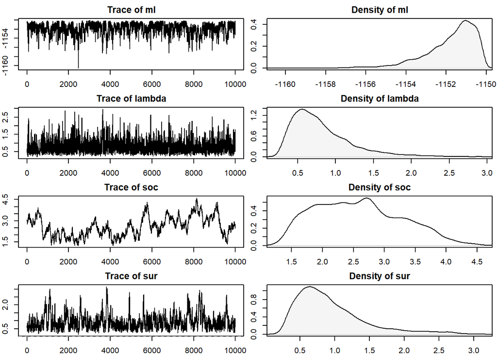

```r
plot(sim.est$bvar1)
```

# Plot the posterior density of the first lag of each variable in each equation

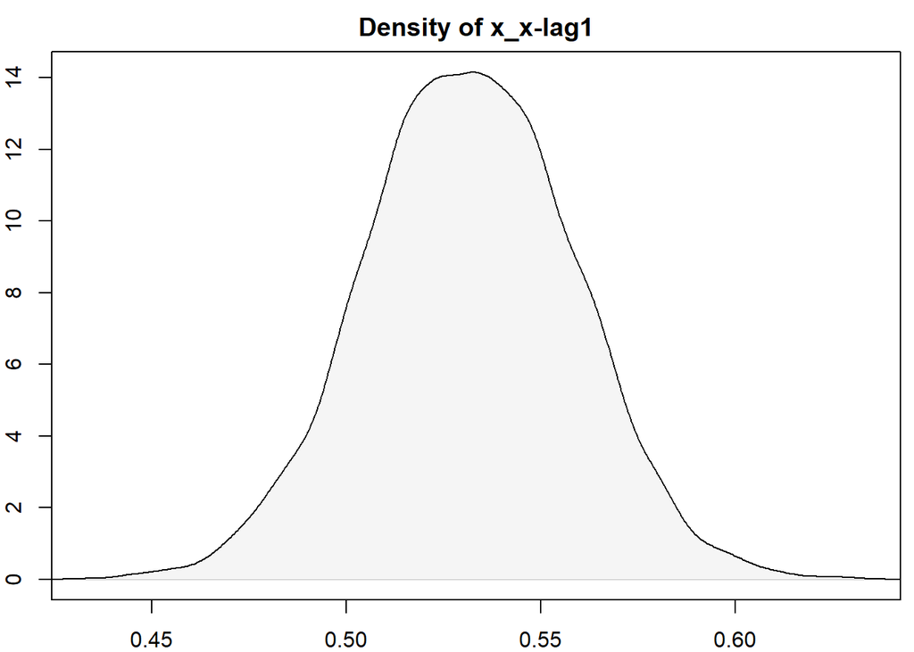

```r
plot(sim.est$bvar1, type = "dens",
     vars_response = "x", vars_impulse = "x")
```

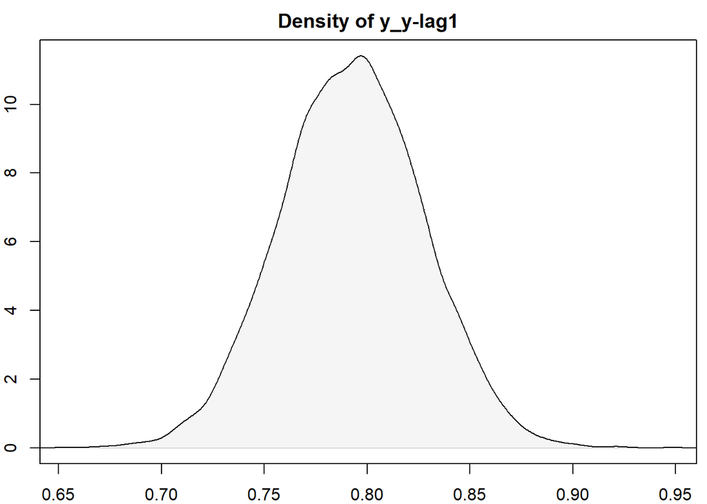

```r
plot(sim.est$bvar1, type = "dens",
     vars_response = "y", vars_impulse = "y")
```

# Fitted and residuals values

```r
fitted(sim.est$bvar1, conf_bands = 0.10)
```

```
## Numeric array (dimensions 3, 399, 2) with fitted values from a BVAR.
## Computed confidence bands: 10%, 50%, 90%
## Median values:
##  x: 7.9, 7.95, 8.17, [...], 8.43, 9.31, 9.4
##  y: 4.26, 5.43, 6.24, [...], 6.84, 6.5, 5.45
```

# plot the residuals

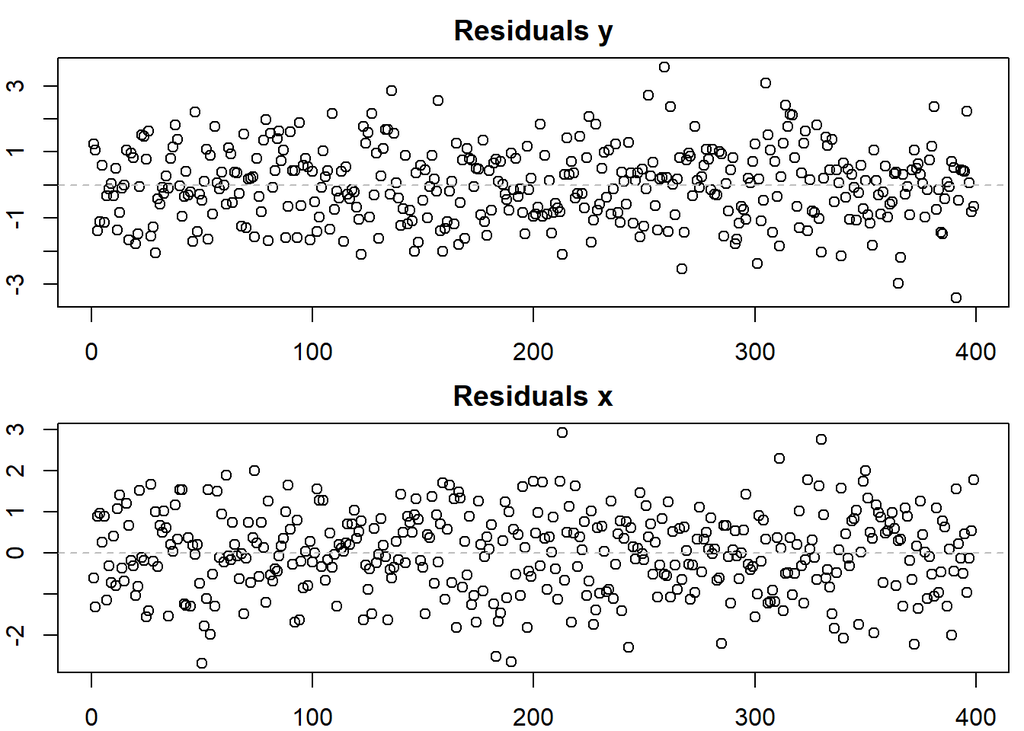

```r
plot(residuals(sim.est$bvar1, type = "mean"), vars = c("y","x"))
```

#—————————————————————————————— # Can construct IRF #——————————————————————————————

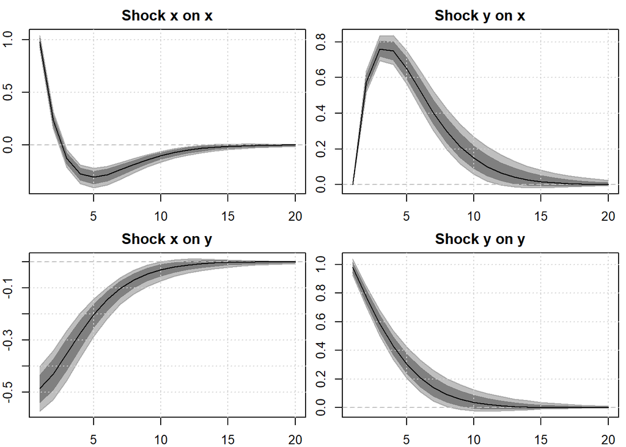

```r
sim_opt_irf <- bv_irf(horizon = 20, identification = TRUE)
irf(sim.est$bvar1) <- irf(sim.est$bvar1, sim_opt_irf, conf_bands =c(0.05,0.16))

plot(irf(sim.est$bvar1), area = TRUE,
     var_impulse = c("y","x"))
```

# Can construct forecast using

```r
sim.fore$bvar1 <- predict(sim.est$bvar1, horizon = 100, conf_bands = c(0.05, 0.16))
```

# Retain only the median forecast

```r
sim.fore$bvar1 <- data.table(sim.fore$bvar1$quants[3,1:100,1:2])
setnames(sim.fore$bvar1, c('x', 'y'))
```

# BVAR(4)

```r
sim.est$bvar4 <- bvar(sim.data[1:400], lags = 4, n_draw = 15000, n_burn = 5000, n_thin = 1,
                      priors = priors, mh = mh, verbose = TRUE)
```

```
## Optimisation concluded.
## Posterior marginal likelihood: -1149.414
## Hyperparameters: lambda = 0.28037; soc = 2.51123; sur = 0.67397
##
## Finished MCMC after 8.25 secs.
```

# print the output of the estimation of the BAVR

```r
print(sim.est$bvar4)
```

```
## Bayesian VAR consisting of 396 observations, 2 variables and 4 lags.
## Time spent calculating: 8.25 secs
## Hyperparameters: lambda, soc, sur
## Hyperparameter values after optimisation: 0.28037, 2.51123, 0.67397
## Iterations (burnt / thinning): 15000 (5000 / 1)
## Accepted draws (rate): 3091 (0.309)
```

# We use to assess convergence of the MCMC algorithm

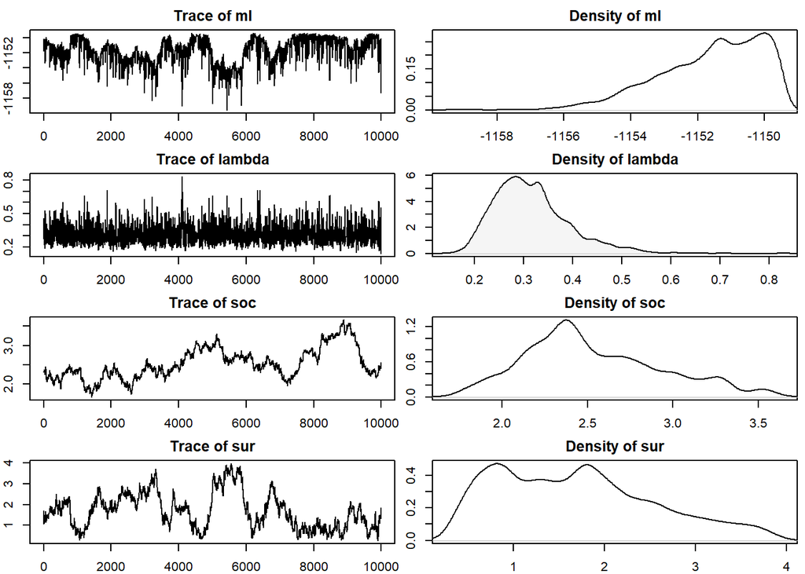

```r
plot(sim.est$bvar4)
```